# Capstone_MaelvDijk_DMaE

Maël

2022-04-14

## Samenvatting

House of Bèta (HoB) blijkt vanaf haar derde jaar een competitief salaris te bieden waarin het meer dan 50% van de markt verslaat. In de eerste tweede jaren verdienen werknemers boven het modale loon. Hierin is zeker te stellen dat HoB een competitief salaris biedt. Het blijkt echter dat HoB nog ruimte heeft om de hard skills van haar personeel te ontwikkelen. Het belangrijkste zijn skills m.b.t cloud, big data, en geavanceerde data science skills. Deze skills worden steeds meer gevraagd door de huidige opdrachtgevers en potentiële nieuwe opdrachtgevers. Wat betreft nieuwe opdrachtgevers blijken er kansen te liggen bij Bertelsmann en Amarant. Als laatste is het belangrijk om de skills sql, python en R te blijven aanbieden en aansterken.

## Inleiding

Dit onderzoek richt zich op de vraag hoe competitief House of Bèta (HoB) is op de markt voor data professionals. Hierin wordt gekeken naar zowel het monetair salaris als de mogelijkheden voor HoB om een groter deel van de markt te bedienen.

HoB heeft al langer de wens om inzichten te krijgen in de reden van uitstroom van haar consultants, gezien dit een belangrijke asset is van de organisatie. Wegens juridische en technische beperkingen is het momenteel niet mogelijk hier een specifiek onderzoek naar te doen.

Deze wens is meer urgent geworden na de uitstroom die het moederbedrijf van HoB, Talent&Pro, in 2021 heeft gezien. HoB verwacht dat deze uitstroom op den duur ook binnen haar eigen consultants zal optreden.

Een tweede wens is om de markt beter te kunnen bedienen en als bedrijf te groeien, zoals gepresenteerd in de doelstellingen van 2022. Deze groei moet plaats vinden op het gebied van het aantal consultants, opdrachten en de diversiteit van deze opdrachten. Door deze wensen en doelstellingen te koppelen helpt dit onderzoek HoB om inzicht te krijgen in een ontwikkelende markt, haar eigen monetaire arbeidsvoorwaarden op waarde te schatten en biedt een basis voor verdere analyse aangaande de uitstroom van haar personeel.

### Businessvraag

De wensen van HoB worden met de volgende onderzoeksvraag onderzocht: “Hoe positioneert HoB zich ten opzichte van andere werkgevers op de Nederlandse arbeidsmarkt van data professionals kijkend naar loon, skills en potentiële opdrachtgevers?”

Deze vraag kan verder worden opgedeeld in drie deelvragen:

1. Hoe verhoudt het salaris van HoB zich tot andere werkgevers op de Nederlandse arbeidsmarkt van data professionals?

2. In hoeverre sluit het cursus,- en opleidingsaanbod van HoB zich aan op de vraag van andere werkgevers op de Nederlandse arbeidsmarkt van data professionals?

3. Welke werkgevers die actief zijn op de Nederlandse arbeidsmarkt van data professionals worden nog niet bediend door HoB?

### Data mining goals

Om tot de businessdoelen te komen zijn er een aantal data mining doelen opgesteld. Gezien HoB nog geen datamining activiteiten uitvoert betekent dit dat een groot deel van dit onderzoek besteed wordt aan ETL.

Allereerst moet er een dataset opgehaald worden met een corpus van skills. Vervolgens moeten vacatures gescraped worden van een representatieve vacaturebank. Daarna moet er textmining plaatsvinden om tot tabulaire data te komen en deze data te verrijken. Als laatste moeten er analyses plaats vinden om de vraag van de business te kunnen beantwoorden.

### Business Success criteria

De volgende kwalitatieve eisen zijn door HoB gesteld: er moet een analyse komen van HoB versus marktinkomen, en een verdeling van de vraag (naar skills) onder bedrijven.

Daarnaast wordt er een bruikbare scraper en andere data analyse artefacten voor vervolg onderzoek opgeleverd.

## Methode

Dit hoofdstuk behandelt de data en het gebruik. In “data understanding” worden kenmerken van de dataset besproken, “data preperation en modelling” gaat in op het schonen en verrijken van de data. Als laatste gaat “reproduceren van het onderzoek” over de reproduceerbaarheid van dit onderzoek.

### Data understanding

Hieronder worden de scope, de gebruikte datasets en kenmerken beschreven.

#### Gekozen datasets en scope

Om te beginnen is hieronder een datalog weergegeven. Dit bevat informatie over de datasets in de ruwe vorm (te vinden in “.\Data_raw”)“.

Tabel 1: datalog (shortened)

| ID | dataset name | format | beschrijving | dataset owner | Locatie |
| --- | --- | --- | --- | --- | --- |
| D001 | indeed_job_dataset.csv | CSV | dataset met job post data vanuit de VS voor data anlysten, scientisten en engineers. | Elroy | extern: https://www.kaggle.com/datasets/elroyggj/indeed-dataset-data-scientistanalystengineer |
| D002 | scraped indeed data.csv | CSV | scraped data voor functies met het woord “data” in nederland | Maël | scraper: ./Supporting_code/indeed_scraper.R |

D001 is gekozen als basis (zie ook hoofdstuk “Addendum” voor aansluitende analyses). Hierin staan onder andere skills en functietypen. Dit legt een goede basis voor dit onderzoek, de functietypen sluiten namelijk aan op de specialisaties binnen HoB. Andere datasets hadden te weinig observaties of misten cruciale gegevens, vandaar de keuze voor D001.

D002 is gescrapte data van Indeed. De rationale achter het scrapen van Indeed komt uit het tekortschieten van bestaande API’s en afwezigheid van relevante datasets. Indeed is gekozen omdat dit een van de grotere vacaturebanken is. Ook kan de scraper andere vacatures binnen halen, niet gerelateerd aan het data domein, wat deze multipurpose maakt.

#### Beschrijving van de ruwe data

Beginnend bij de beschrijving van D001. Deze dataset is al erg opgeschoond. De basale kenmerken zijn in onderstaande overzicht te vinden. Voor dit onderzoek lijken gelijk twee kolommen interessant. Dit zijn “Skill” en “Job_Type”. Hierin staan respectievelijk een lijst van (hard)skills en de functietypen per observatie.

```
df_indeed_kaggle

 43  Variables      5715  Observations
------------------------------------------------------------
X
       n  missing distinct     Info     Mean      Gmd
    5715        0     5715        1     2857     1905
     .05      .10      .25      .50      .75      .90
   285.7    571.4   1428.5   2857.0   4285.5   5142.6
     .95
  5428.3

lowest :    0    1    2    3    4, highest: 5710 5711 5712 5713 5714
------------------------------------------------------------
Job_Title
       n  missing distinct
    5715        0     2314

lowest : 1244527 - Senior Data Scientist           1244529 - Data Scientist                  1244531 - Data Scientist                  16th EWS Mssion Data Engineer             2019 PhD Data Scientist Internship - Maps
highest: WIC Senior Data Analyst                   Wireless Data Scientist                   Work Force Analytics Analyst              Workforce Data Analyst                    XTO Land Data Analyst
------------------------------------------------------------
Link
       n  missing distinct
    5715        0     5715

lowest : https://www.indeed.com/company/ABC-Supply-Co.-Inc/jobs/Data-Scientist-49adcb479d6a010a?fccid=042d4158e141fbb6&vjs=3 https://www.indeed.com/company/Accenture/jobs/Aws-Big-Data-Engineer-01afdcbc43d0169e?fccid=a4e4e2eaf26690c9&vjs=3   https://www.indeed.com/company/Accenture/jobs/Aws-Big-Data-…
highest: https://www.indeed.com/rc/clk?jk=ffd4463e2660a73e&fccid=f766f8bfbc3effb7&vjs=3                                      https://www.indeed.com/rc/clk?jk=ffd59bd7e4b9d777&fccid=7cb8926c790321ab&vjs=3                                      https://www.indeed.com/rc/clk?jk=ffe8067a782cd820&fccid=b7f…
------------------------------------------------------------
Queried_Salary
       n  missing distinct
    5715        0        6

lowest : <80000        >160000       100000-119999 120000-139999 140000-159999
highest: >160000       100000-119999 120000-139999 140000-159999 80000-99999

Value             <80000       >160000 100000-119999
Frequency            788           415          1394
Proportion         0.138         0.073         0.244

Value      120000-139999 140000-159999   80000-99999
```

[output cut: 501 more lines]

```
------------------------------------------------------------
Insurance
       n  missing distinct     Info      Sum     Mean
    5715        0        2    0.114      227  0.03972
     Gmd
  0.0763

------------------------------------------------------------
Other_industries
       n  missing distinct     Info      Sum     Mean
    5715        0        2     0.56     1421   0.2486
     Gmd
  0.3737

------------------------------------------------------------
```

Het overzicht hierboven toont onder andere dat het aantal unieke “Skills” bijna gelijk is aan het aantal unieke rijen. Hier zit echter een fout. Het is namelijk zo dat [SQL, Python] en [Python, SQL] hetzelfde betekenen maar wordt gezien als twee unieke rijen. Daarnaast is het opvallend dat de verdeling tussen data analist (31%), data engineer (24%) en data scientist (45%) niet evenredig is.

Dataset D002 bevat Indeed data. Hiervoor is er gescraped naar functies met het woord “data”. D002 bestaat uit meerdere losse bestanden (één voor elke dag dat er een run is geweest). Hieronder de voornaamste kenmerken van de run van 2022-03-08:

```
df_indeed_scraped

 9  Variables      328  Observations
------------------------------------------------------------
X
       n  missing distinct     Info     Mean      Gmd
     328        0      328        1    164.5    109.7
     .05      .10      .25      .50      .75      .90
   17.35    33.70    82.75   164.50   246.25   295.30
     .95
  311.65

lowest :   1   2   3   4   5, highest: 324 325 326 327 328
------------------------------------------------------------
Company
       n  missing distinct
     328        0      226

lowest : &More Interim          247 Tailor Steel       5CA                    a.s.r.                 Accenture
highest: World of Content       Xebia Group            Young Heroes Community Young Mavericks        YoungCapital
------------------------------------------------------------
job_title
       n  missing distinct
     328        0      177

lowest : (Jr.) Data Analist                              (Junior) consultant big data en vastgoedsturing (Junior) Data Scientist                         (Sr.) Data Officer                              Associate Party & ESG data
highest: Wanted: Data junkie!                            Werkstudent Data & Analytics Sofy               Werkstudent Data Analist M/V                    Werkstudent Data Analytics                      Young Hero - Data
------------------------------------------------------------
salary
       n  missing distinct
     171      157       98

lowest : ï¿½ 11,27  ï¿½ 2.023  ï¿½ 2.407  ï¿½ 2.426  ï¿½ 2.500
highest: ï¿½6.390 p ï¿½6.750 - ï¿½60.000  ï¿½70.000  ï¿½95.000
------------------------------------------------------------
skills
       n  missing distinct
     293       35      200

lowest : agriculture, python, linux, scripting    ai                                       ai, deep, rest, tableau, sql, postgresql ai, informatica, sql                     ai, lean, marketing
```

[output cut: 18 more lines]

```
------------------------------------------------------------
job_link
       n  missing distinct
     328        0      283

lowest : https://nl.indeed.com/company/247TailorSteel-B.V./jobs/Data-Scientist-623dbe1e735af094?fccid=7e868bea49ce706f&vjs=3                     https://nl.indeed.com/company/ADchieve/jobs/Data-Scientist-7fde413529cf182a?fccid=4487d6e49bad8b7b&vjs=3                                https://nl.indeed.c…
highest: https://nl.indeed.com/rc/clk?jk=fca44376417ebefe&fccid=119c6a932b23877c&vjs=3                                                           https://nl.indeed.com/rc/clk?jk=fd31842aa90f1864&fccid=7f9f2b3c5ddde775&vjs=3                                                           https://nl.indeed.c…
------------------------------------------------------------
listing_date
       n  missing distinct
     327        1       21

lowest : 2022-02-06 2022-02-08 2022-02-09 2022-02-10 2022-02-11
highest: 2022-03-02 2022-03-03 2022-03-04 2022-03-05 2022-03-08
------------------------------------------------------------
```

Afgaande op de kenmerken wordt duidelijk dat:

1. De dataset heeft als vroegste datum 6 februari 2022
2. Er zijn geen volledige dubbele rijen.
3. 283 rijen unieke URL’s en 266 rijen unieke beschrijvingen bevatten. Dit duidt op dubbele vacatures.
4. Er zijn 226 bedrijven in de dataset aanwezig.
5. Het salaris lijkt foute symbolen te bevatten en lijkt zowel uur-, maand-, en jaarsalarissen te bevatten.
6. Een vacature lijkt gemiddeld 22 dagen online te staan met een mediaan van 30 dagen. Wat aangeeft dat er relatief weinig nieuwe vacatures op de dag van scrapen zijn geplaatst.

Uiteindelijk lijkt de dataset vrij goed geconstrueerd op de kolommen met skills en salaris na. Ook mist er informatie over functietypen.

### Data preperation en modeling

Onderstaande processflow geeft in grote lijnen het proces van ruwe data tot resultaat weer.

Het volledige proces bestaat uit drie segmenten. Bovenin betreft D001. Segment twee (midden) betreft D002. Onderin staat segment drie waarin het eindresultaat weergegeven wordt.

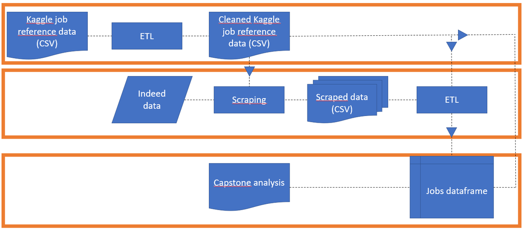

Figuur 1: Data process flow

Omdat de tijd beperkt is voor dit onderzoek zijn er een aantal aannames gedaan om problemen te voorkomen en de complexiteit te verkleinen, verder wegens beperkte tijd en de afwezigheid van een ML model is er voor gekozen om de missende waarden niet onderhanden te nemen:

Tabel 2: Aannamens tijdens process stappen,

| Process stap | Betreffende kolom | Versimpelde weergaven |
| --- | --- | --- |
| Scraping | Salary | Er is bij weergaven salarissen altijd voor het laagste salaris gegaan |
| ETL (midden-rechts) | job_type | Er zijn drie type (analist, engineer, scientist). De dataset wordt verrijkt met een van deze type zelfs al wijkt dit af. Zo kan de functie “data entry” als “data analist” worden geclassificeerd. |
| ETL (midden-rechts) | salary | Salaris > 10.000 is jaarsalaris of salaris < 100 is uur tarief. Dit wordt omgerekend naar maandsalaris (delen door 12 of maal 162 respectievelijk). Alles tussen de 100 en 1000 wordt als scraping fout … |

De scripts voor deze stappen zijn te vinden in “./Supporting_code”:

Tabel 3: process stappen en bijbehorende scripts.

| Process stap | Script naam |
| --- | --- |
| ETL (linksboven) | Generate_ref_skill_list.R |
| Scraping | indeed_scraper.R |
| ETL (midden-rechts) | Scraped_indeed_data_wrangler.R |

De scripts en betreffende functies zorgen voor een dataset die gebruikt kan worden voor dit onderzoek. De scripts zijn voorzien van helpende comments om het gebruik te vergemakkelijken.

### Reproduceren van het onderzoek

De mappen: “Data_cleaned”, “Data_raw”, en “Supporting_code” bevatten alle data en code die nodig is om dit onderzoek te reproduceren. In dit markdown document worden de data en benodigde scripts aangeroepen om tot het eindresultaat te komen. De benodigde R libraries zijn: “tidyverse”, “stringr”, “lubridate”, “tibble”, “textTinyR”, “XML”, “rvest”, “tseries”.

Verder is aan het eind van dit document een hoofdstuk “Addendum” toegevoegd. Dit zijn stukken code en analyses geschreven ten behoeven van het onderzoek maar wegens ruimte gebrek of de statistische betrouwbaarheid achterwegen gelaten.

## Resultaten

Dit hoofdstuk beantwoord de deelvragen aan de hand van diverse analyses. Ook wordt besproken welke vragen (nog) niet kunnen worden beantwoord en welke artefacten worden aangeleverd.

### Hoe verhoudt het salaris van HoB zich tot andere werkgevers op de Nederlandse arbeidsmarkt van data professionals?

De grafiek hieronder geeft de salaris verdeling van data vacatures op Indeed weer. Het eerste wat duidelijk wordt is dat het loon bij HoB boven modaal ligt. Daarnaast is het salaris in jaar drie hoger dan 50% van de salarissen geboden op Indeed.

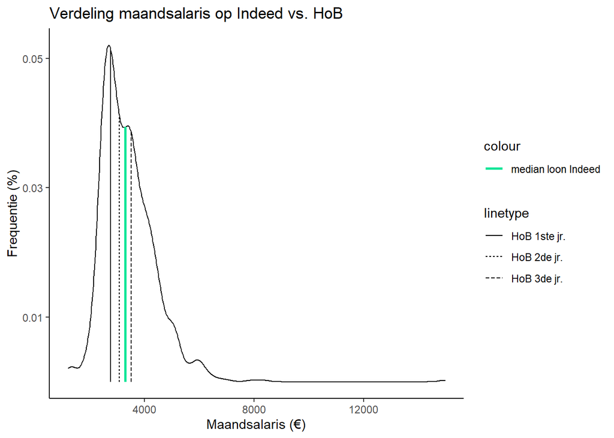

Bovenstaande analyse zegt echter niet alles. Hierin worden drie verschillende maandsalarissen van HoB vergelijken met de gehele onderzoekspopulatie.

Hieronder is de salaris verdeling te zien gesegmenteerd op gevraagde ervaring in de vacatures. Door dataset D002 (1614 observaties) op te delen in negen segmenten op basis van gevraagde jaren werkervaring is de verdeling gevoeliger en minder accuraat. Toch geeft het de indruk dat het salaris geboden door HoB doorgaans beter is dan het salaris op Indeed.

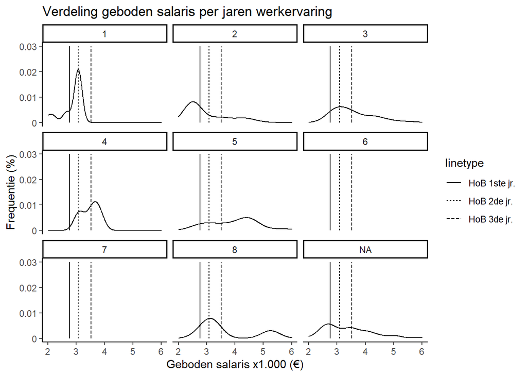

Het salaris bij HoB wordt niet alleen bepaalt door werkervaring. Ook het afronden van cursussen en het opdoen van skills wordt beloond. Wat betreft hard skills kan er vanuit worden gegaan dat een consultant vier tot zes skills bezit na de eerste drie jaar bij HoB. Dit zijn data modeling, excel, R, Python, SQL en PowerBI.

In onderstaande drie grafieken is het mediaan salaris op Indeed weergegeven verdeeld over het gevraagde aantal skills. De zwarte lijn geeft het bijbehorende HoB salaris aan. De balken kleuren groen op het moment dat het salaris van HoB hier boven ligt.

Vanaf het derde jaar blijkt HoB echt een competitief salaris te bieden. Hierbij kan verwacht worden dat een consultant zo’n vier tot zes skills bezit. Daarmee verslaat het de markt kijkend naar skill,-, loonratio.

#### 1ste jaars HoB

[figure not shown]

```r
plot_indeed_median_salary_per_amount_skills(
    df_indeed_final,
    add_ref_line= TRUE,
    ref_salary= 2763
)
```

#### 2de jaars HoB

[figure not shown]

```r
plot_indeed_median_salary_per_amount_skills(
    df_indeed_final,
    add_ref_line= TRUE,
    ref_salary= 3087
)
```

#### 3de jaars HoB

[figure not shown]

```r
plot_indeed_median_salary_per_amount_skills(
    df_indeed_final,
    add_ref_line= TRUE,
    ref_salary= 3519
)
```

Bovenstaande analyse zou nog verdiept kunnen worden in een vervolg onderzoek door het gevraagde aantal jaren werkervaring mee te nemen als extra dimensie. Dit levert nu echter te weinig observaties (11) per categorie op.

### In hoeverre sluit het cursus,- en opleidingsaanbod van HoB zich aan op de vraag van andere werkgevers op de Nederlandse arbeidsmarkt van data professionals?

Deze deelvraag behoeft twee analyses. Enerzijds is het van belang om te weten hoe het huidige aanbod van HoB aansluit op de huidige vraag. Daarnaast is het van belang om te weten hoe de vraag naar Skills zich ontwikkelt. Door gebrek aan data is dit laatste lastig te analyseren toch wordt hiertoe een poging gedaan.

Allereerst, de huidige vraag naar skills. Hieronder zijn twee grafieken te vinden. De eerste grafiek geeft de top 20 skills weer, de tweede grafiek de minst gevraagde 20.

#### top skills

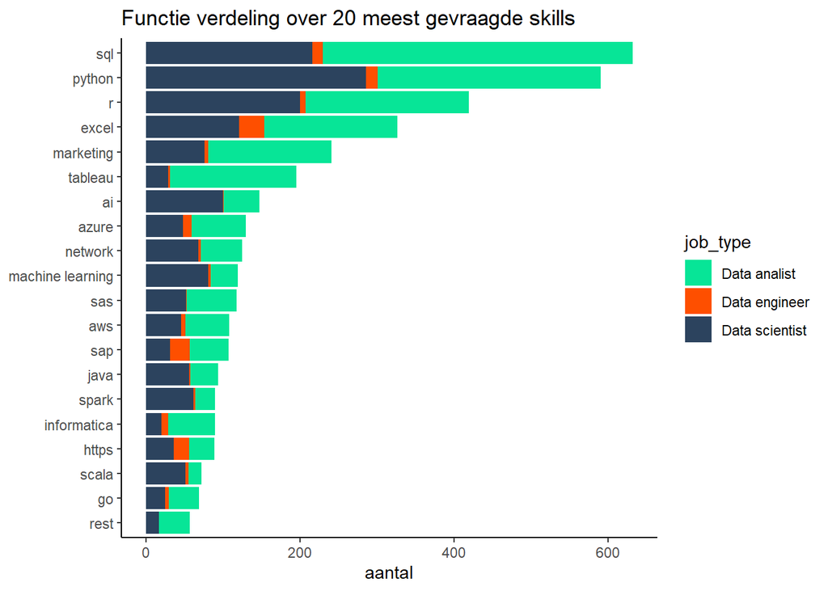

```r
# get sorted vector of all skills
all_skills <- df_indeed_skills$skills %>% sort(decreasing= TRUE)

# create a top and bottom 20
top_skills <- table(df_indeed_skills$skills) %>% sort() %>% tail(20)
bottom_skills <- table(df_indeed_skills$skills) %>% sort() %>% head(20)

# plot top skills
df_indeed_skills %>%
    # filter df based on most sought skill
  filter(skills %in% names(top_skills)) %>%
  ggplot(
      aes(
        x = reorder(
          skills,
          skills,
          function(x) + length(x) # decreasing order skill
          ),
          fill= job_type
          )
      ) +
  geom_bar() +
  theme(
    axis.text.y = element_text(
      face= 'bold',
      size= 14)) + # Rotate x-labels and change font
      coord_flip() +
  labs(
    title= "Functie verdeling over 20 meest gevraagde skills",
    y= "aantal"
  )+
  theme_classic()+
  theme(axis.title.y=element_blank())+
  scale_fill_manual(values=HoB_color_palet)
```

#### Bottom skills

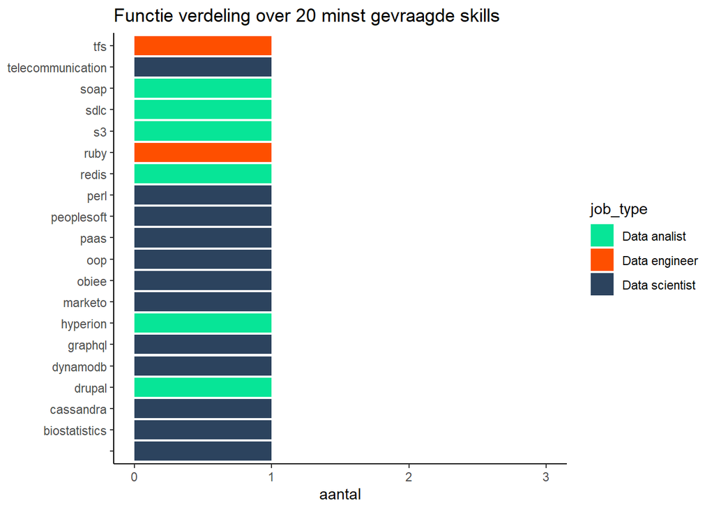

```r
# plot bottom skills
df_indeed_skills %>%
    # filter df based on least sought skill
  filter(skills %in% names(bottom_skills)) %>%
  ggplot(
      aes(
        x = reorder(
          skills,
          skills,
          function(x) + length(x) # decreasing order skill
          ),
          fill= job_type
          )
      ) +
  geom_bar() +
  theme(
    axis.text.y = element_text(
      face= 'bold',
      size= 14)) + # Rotate x-labels and change font+
  scale_y_continuous(
      breaks= seq(0, 3, 1),
      labels=seq(0, 3, 1),
      limits= c(0,3)
    )+
      coord_flip() +
  labs(
    title= "Functie verdeling over 20 minst gevraagde skills",
    y= "aantal"
  )+
  theme_classic()+
  theme(axis.title.y=element_blank())+
  scale_fill_manual(values=HoB_color_palet)
```

Gezien bij HoB momenteel de nadruk wordt gelegd op Python, SQL, R, SAS, PowerBi en cloud (AWS, Azure) technologie, sluit dit goed aan op de huidige vraag binnen de markt. Een gat blijkt te zitten in de specifieke vaardigheid “Tableau” waar geen cursus voor wordt geboden door HoB en de afwezigheid van opleidingen in de richting van big data en specifieke data science skills (spark, ai, (neural) networks, etc.)

Gezien er geen overlap zit tussen de opleidingen die HoB biedt en de minst gevraagde skills lijkt er momenteel geen reden te zijn om met bepaalde opleidingen te stoppen.

Interessant om nog op te merken: SQL en Python beslaan 24% van de totale vacatures, wordt R ook meegenomen dan is dit 32%. Een focus op alleen dit deel van de skills lijkt een goed deel van de markt te dekken. Dit zijn dus absoluut skills waar de focus op moet blijven liggen.

#### Ontwikkeling skillbehoeften

Met de huidige ontwikkelingen op het gebied van big data en cloud technologie die in de praktijk zichtbaar zijn is het aannemelijk dat het merendeel van deze top 20 alleen maar belangrijker gaan worden.

Om een sterke trend analyse te doen is minstens ~3 jaar aan data nodig. Dit is een beperking die verder in het hoofdstuk “discussie” wordt besproken.

Hieronder zijn zes skills gekozen die in iedergeval in de gaten gehouden kunnen worden. Momenteel vertellen de grafieken dat de vraag doorgaans dalende is (groene trendlijn) echter is de aannamen dat na het verzamelen van meer data een duidelijke opwaartse trend zichtbaar zal worden. Deze aannamen is op basis van ervaring binnen de consultancy waar minder opdrachten beschikbaar zijn, vaak als gevolg van nieuwe budgetering en invulling van deze budgetten door organisaties.

Mocht de behoeften aanwezig zijn om andere skills te onderzoeken dan kan de bijbehorende code makkelijk worden aangepast.

#### SQL

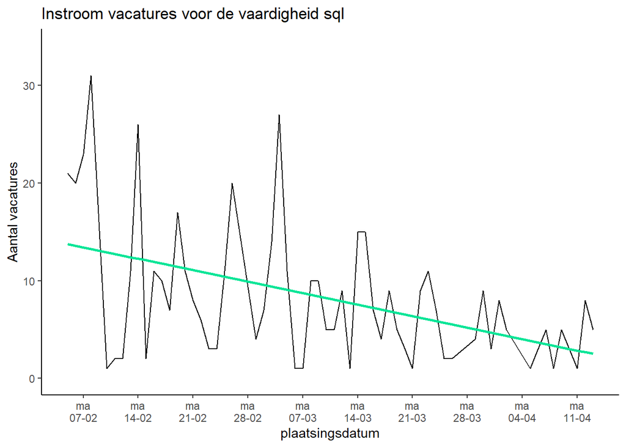

```r
plot_indeed_timeseries_data(df_indeed_skills_date_filtered, "sql")
```

#### Python

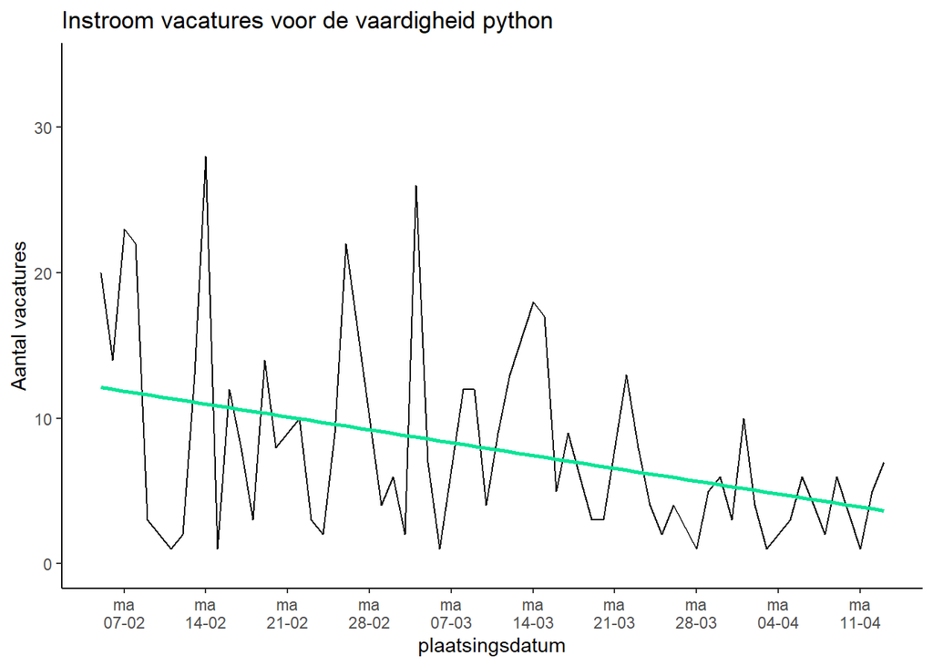

```r
plot_indeed_timeseries_data(df_indeed_skills_date_filtered, "python")
```

#### R

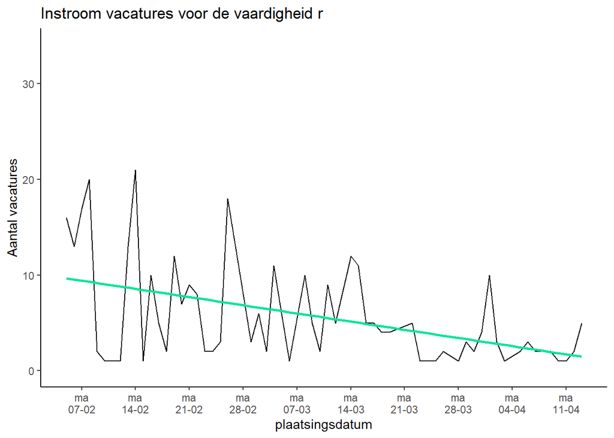

```r
plot_indeed_timeseries_data(df_indeed_skills_date_filtered, "r")
```

#### Tableau

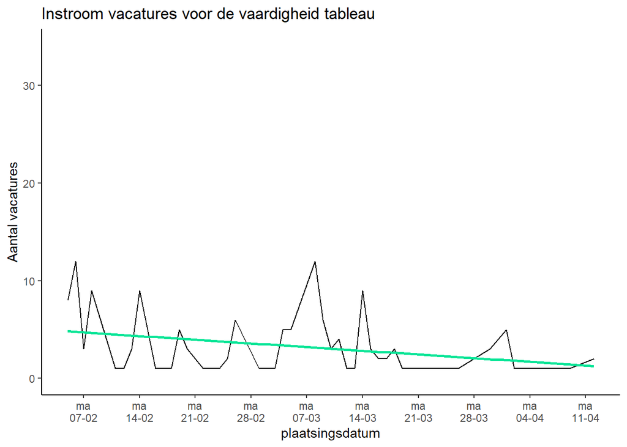

```r
plot_indeed_timeseries_data(df_indeed_skills_date_filtered, "tableau")
```

#### Azure

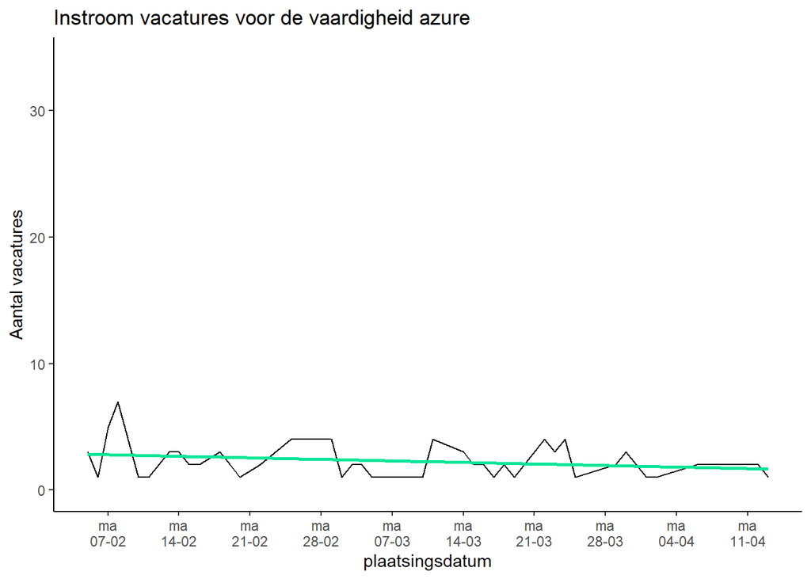

```r
plot_indeed_timeseries_data(df_indeed_skills_date_filtered, "azure")
```

#### AWS

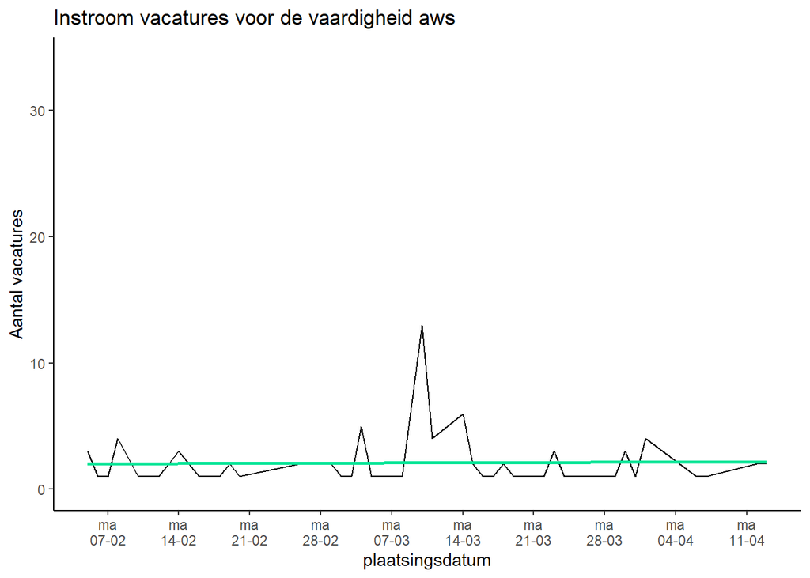

```r
plot_indeed_timeseries_data(df_indeed_skills_date_filtered, "aws")
```

### Welke werkgevers die actief zijn op de Nederlandse arbeidsmarkt van data professionals worden nog niet bediend door HoB?

De laatste deelvraag binnen dit onderzoek richt zich op de mogelijke opdrachtgevers. Hiervan was het oorspronkelijk de bedoeling om een trend analyse te doen per bedrijf. Echter is dit door het tekort aan data niet te realiseren. In plaats daarvan wordt hier gekeken naar de huidige gap tussen de organisaties die vacatures uit hebben staan op Indeed en de organisaties die HoB bedient. Wel is in de bijlagen “Addendum” een stuk over de trend van de algehele markt te vinden.

Buiten dat de data lijkt uit te wijzen dat er grote vraag naar data professionals is, is het vooral interessant om te kijken naar de organisaties met de hoogste vraag die niet vallen onder consultancy of detacheerders. In de grafiek “top 10 bedrijven (excl. detachering) - functie types” is een subset gemaakt van deze 25 bedrijven zonder consultancies of detacheerders. Uit deze grafiek zijn op dit moment twee partijen waar HoB geen personeel aan levert: Bertelsmann SE & Co, en Amarant.

Uiteraard is dit een summiere analyse om een daadwerkelijke gap aan te tonen vandaar nog twee aanvullende analyses. De grafiek “top 10 bedrijven - top 10 skills (gehele populatie)” laat zien dat voornamelijk python, sql, R, ai en (neural) network skills veel gezocht wordt door de subset van bedrijven. De grafiek “Top 10 bedrijven - top 10 skills (binnen top 10 bedrijven)” laat eenzelfde verdeling zien maar dan vanuit een andere invalshoek. De eerste van deze twee grafieken beschouwt de meest gevraagde skills vanuit de hele onderzoeks populatie. De tweede grafiek daarentegen laat toont alleen de top skills die daadwerkelijk door deze bedrijven worden gezocht. Uit deze laatste grafiek komen drie inzichten naar voren. De belangrijkste skills blijven ongewijzigd, SAS (HoB focust hier sinds kort op) komt naar voren op de 5e plek. De overige vijf skills hebben veelal te maken met big data toepassingen.

#### top 25 bedrijven - functie types

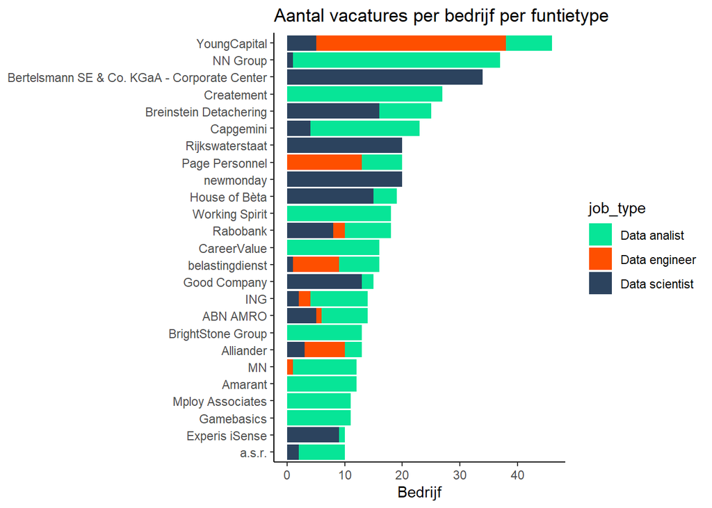

```r
top_companies <- table(df_indeed_final$Company) %>%
  sort() %>%
  tail(25) %>%
  names()

plot_job_type_per_company(df_indeed_final, top_companies)
```

#### top 10 bedrijven (excl. detachering) - functie types

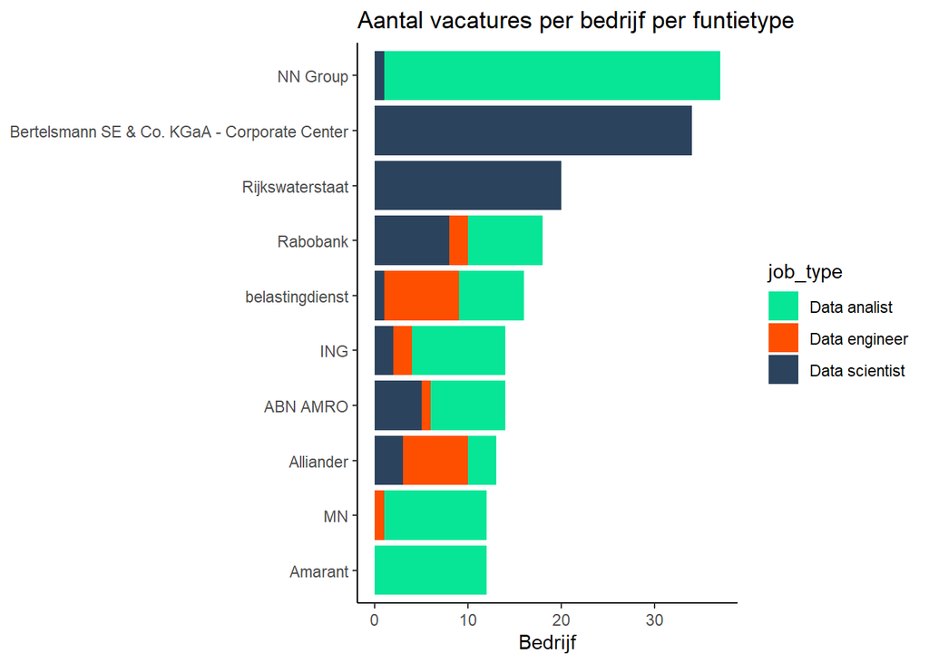

```r
# get top 10 companies not being consultancies and others alike
companies_of_interest <- c(
  "Bertelsmann SE & Co. KGaA - Corporate Center",
  "NN Group",
  "Rabobank",
  "belastingdienst",
  "Rijkswaterstaat",
  "Alliander",
  "MN",
  "ING",
  "Amarant",
  "ABN AMRO"
)

plot_job_type_per_company(df_indeed_final, companies_of_interest)
```

#### top 10 bedrijven - top 10 skills (gehele populatie)

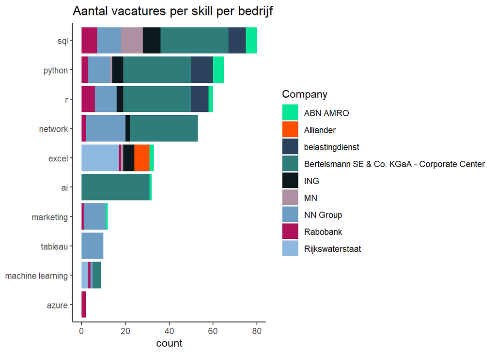

```r
important_skills_full_pop <- table(df_indeed_skills$skills) %>%
  sort() %>%
  tail(10) %>%
  names()

plot_skills_per_company(
  df_indeed_skills_date_filtered,
  companies_of_interest,
  important_skills_full_pop
)
```

#### Top 10 bedrijven - top 10 skills (binnen top 10 bedrijven)

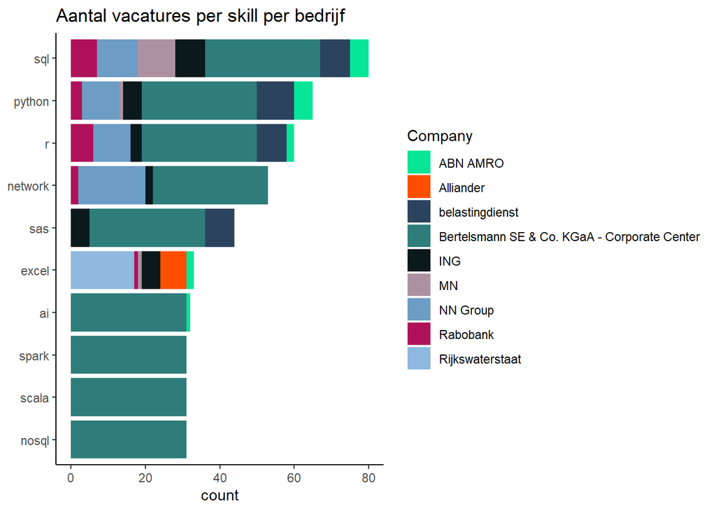

```r
df_important_companies <- df_indeed_skills_date_filtered %>%
  filter(Company %in% companies_of_interest)

important_skills <- table(df_important_companies$skills) %>%
  sort() %>%
  tail(10) %>%
  names()

plot_skills_per_company(
  df_indeed_skills_date_filtered,
  companies_of_interest,
  important_skills
)
```

Een kanttekening: Bertelsmann SE & Co. lijkt de uitslag van de top 10 analyses te beïnvloeden door hun sterke aanwezigheid. NN Group heeft deze invloed blijkbaar minder ondanks het hoger aantal geplaatste vacatures. Dit lijkt te komen omdat NN in al haar vacatures minder vaak skills benoemd (totaal 152) dan Bertelsmann (totaal 388).

Ook inzicht in de concurrentie kan waardevol zijn, dit kan namelijk de vraag naar vaardigheden weergeven van organisaties die openstaan voor consultancy of detachering. De aannamen is dat andere detacheerders vragen naar skills die hun opdrachtgevers zoeken, nu en toekomstig. In de grafiek hieronder zijn de meest gevraagde skills onder de top 10 detacheerders getoond. Hieruit lijken drie nieuwe skills naar voren te komen, namelijk: Stata, Matlab en Gis. Omdat niet veel partijen hier op in zetten lijkt dit niet een belangrijke set skills voor algehele marktbediening.

#### Top 10 skills per detacheerder

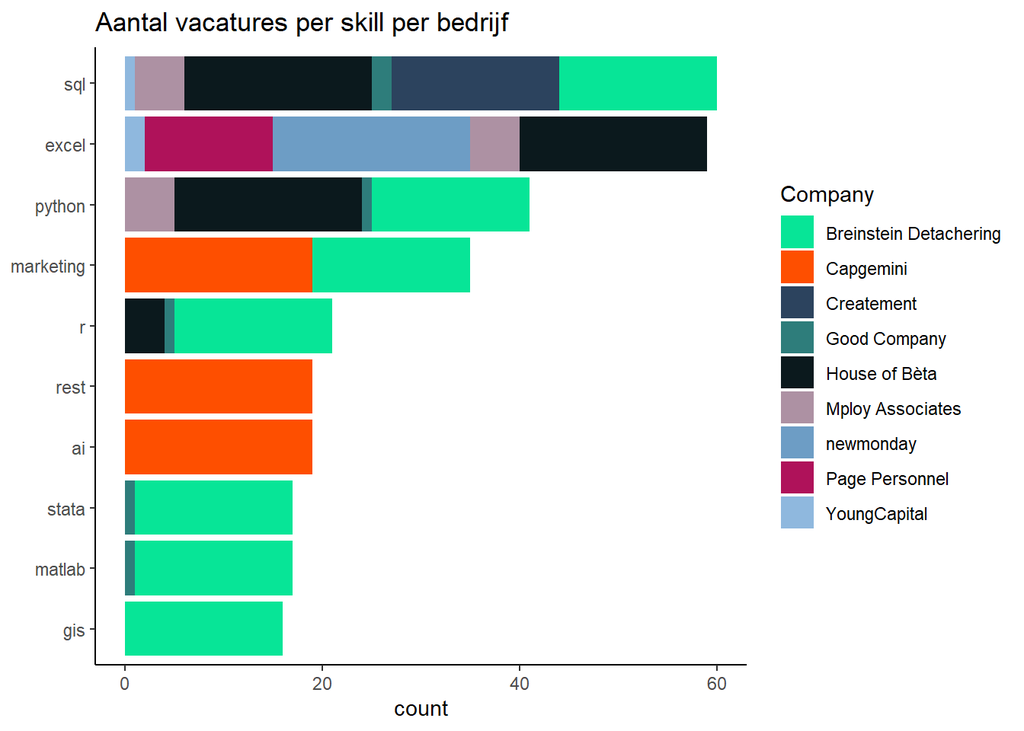

```r
deta_of_interest <- c(
  "YoungCapital",
  "Createment",
  "Breinstein Detachering",
  "Capgemini",
  "Page Personnel",
  "newmonday",
  "House of Bèta",
  "CarreerValue",
  "Good Company",
  "Mploy Associates"
)

df_important_deta <- df_indeed_skills_date_filtered %>%
  filter(Company %in% deta_of_interest)

important_skills_deta <- table(df_important_deta$skills) %>%
  sort() %>%
  tail(10) %>%
  names()

plot_skills_per_company(
  df_indeed_skills,
  deta_of_interest,
  important_skills_deta
  )
```

Om deze deelvraag kort samen te vatten: HoB heeft een kans om bij Bertelsmann SE &Co. en Amarant nieuwe opdrachten binnen te halen, mits zij openstaan voor detachering en/of consultancy. Om haar positie bij partijen te versterken is het naast bestaande cursussen nog waardevol om te kijken naar big data en gevorderde data science skills.

## Discussie

In dit hoofdstuk komen de verbeterpunten en tekortkoming aanbod. Ook wordt er aandacht besteed aan de deployement en daadwerkelijke deliverables.

### Data omvang

Allereerst de omvang van de dataset. Een groot deel van dit onderzoek is beantwoord met de beschikbare data. Echter zijn verdiepingen op trend analyses achterwegen gelaten alsmede analyses over meerdere dimensies waarvoor de dataset te klein is. Bij aanvang van dit project was de inschatting van de hoeveelheid data die binnengehaald kon worden niet direct duidelijk. Het voornaamste verbeterpunt is om de dataset uit te breiden voor verdere analyses. Een leerpunt is dat analyses over drie dimensies een dataset erg zullen versnipperen, hier moet volgende keer rekening mee gehouden worden bij het beoordelen van het aantal nodige observaties.

### Data kwaliteit

Datakwaliteit is al kort aangestipt door het project heen. Het ontbreken van een API en de tijdsdruk voor dit onderzoek heeft betekend dat er keuzes zijn gemaakt in het scrapen, schonen en verrijken van de data. De belangrijkste issues zitten in functietype en skills.

Er is onderscheid gemaakt tussen analist, engineers, en scientisten. Hoewel er vacatures kunnen zijn voor hele andere data functies is iedere functie in een van deze catagorieën geforceerd.

De tweede kwaliteit issue zit in de skills. Een goed voorbeeld is de vaardigheid “network”. Dit had waarschijnlijk “neural network” moeten zijn. Ook zijn skills zoals “sql” in veel verschillende varianten te vinden zoals “mysql”. Deze skills zijn apart opgeslagen, dit geeft een vertekende weergaven van de vraag naar de echte skills. Dit geldt ook van typefouten in de vacaturetekst.

### Data scraping

Als laatste zijn er twee kanttekeningen bij het data scrapen. Allereerst is alleen Indeed als bron gebruikt. Deze bron lijkt representatief en goed te benutten. De keuze om niet meerdere scrapers voor verschillende vacaturebanken te gebruiken is het gebrek aan tijd en het risico van dubbele vacatures.

Het tweede punt betreft de query. De scraper is gericht op een zo breed mogelijk profiel. Om deze reden is als zoekopdracht “data” gebruikt. Een voorgestelde verbetering is de scraper om te bouwen naar een generieke scraper. Hierbij kan de query vrij worden ingevuld en opgeslagen in een variabele die ook wordt opgeslagen in de dataset. Voor dit onderzoek zou dit hebben geholpen om accurater te zoeken naar analisten, engineers, en scientisten. Dit sluit aan op de verdere kritiek onder “data kwaliteit”.

### Deployment

Bij dit onderzoek worden een aantal artefacten aangeleverd die gebruikt kunnen worden voor analyses. De code is voorzien van commentaar en kan relatief makkelijk worden uitgebreid met nieuwe functionaliteiten waar nodig.

Gezien HoB haar IT landschap aankoopt en niet zelf ontwikkelt zullen de artefacten niet standaard in de een productie omgeving draaien. Waarschijnlijker is dat de artefacten voor ad-hoc analyses toegepast kan worden voor verder onderzoek wanneer nodig. Tot die tijd zal de code te vinden zijn in een publieke repo op GitHub: https://github.com/MaelvanDijk/DMAE.

## Conclusie

Hoe positioneert HoB zich ten opzichte van andere werkgevers op de Nederlandse arbeidsmarkt van data professionals kijkend naar loon, skills en potentiële opdrachtgevers?

Het is duidelijk geworden data HoB een competatief salaris biedt aan haar medewerkers, In iedergeval vanaf jaar drie waar zij meer dan 50% van de vacatures in loon voorbijgaan. Voor zowel jaar een, twee, en drie verdient een HoB consultant boven modaal. Kijkende naar de gehele onderzoeks populatie. Hierin lijkt er, afgaande op het markt aanbod van monetair salaris, niet direct een aanleiding te zijn voor uitstroom bij HoB. Hierbij moet wel gesteld worden dat aanbiedingen van opdrachtgevers om collega’s direct over te nemen na hun opdracht niet meetbaar zijn en daarbij kunnen afwijken van de aanbiedingen zichtbaar op Indeed.

Op het gebied van skills en opdrachtgevers doet HoB het goed. Zij bedient een groot deel van de bedrijven die de meeste vacatures uit hebben staan. Hierin bestaat voor HoB de kans om met Amarant en Bertelsmann zaken te gaan doen. Wat betreft de skills is het belangrijk dat HoB blijft inzetten op de belangrijkste skills (sql, python en r) maar ook de verdieping aanbiedt op het gebied ai, neurale netwerken en big data oplossingen (scala, spark en hive).

Kortom HoB lijkt competitief zowel op loon als aanbod waarbij kansen bestaan om vooral naar opdrachtgevers toe verder uit te breiden in zowel skills als partners.

Om tot deze conclusie te komen zijn naast de analyses in het hoofddocument nog andere analyses gedaan deze zijn te vinden in de bijlagen “Addendum”.